# es

## Elastic-Search实战——结合文本分析，推荐算法和元启发式算法实现资源自动分配

### 案例介绍

工作中有很多工作调度和资源匹配的场景，比如客服，技术支持或工单分派：带有文本描述的工单被录入系统，模糊匹配资源库中的人力资源，然后被分配给最适合的人处理。在一些场景中，工单的执行结果和评价也会被记录，作为工单分派信息的一部分被保留。

由于场景复杂而且缺少标准化的问题描述，很多这类匹配问题仍然依赖人工，造成匹配时间延迟，匹配资源基于个人喜好和习惯而非基于可量化的标准。另外由于工单和资源的数据量巨大，一般的数据库查询很难满足实时查询需求。

为了解决查询性能和文本模糊匹配的问题，在案例中尝试使用了工业级实时分布式搜索引擎ElasticSearch，并结合元启发式算法simulated annealing根据历史数据寻找各个搜索键值的权重提升匹配准确度。

### ElasticSearch简介

[ES简介原文链接](https://blog.csdn.net/laoyang360/article/details/52244917)

1. 背景

   1.1 思考：大规模数据如何检索？

   ```
    如：当系统数据量上了10亿、100亿条的时候，我们在做系统架构的时候通常会从以下角度去考虑问题：

    1）用什么数据库好？(mysql、sybase、oracle、达梦、神通、mongodb、hbase…)

    2）如何解决单点故障；(lvs、F5、A10、Zookeep、MQ)

    3）如何保证数据安全性；(热备、冷备、异地多活)

    4）如何解决检索难题；(数据库代理中间件：mysql-proxy、Cobar、MaxScale等;)

    5）如何解决统计分析问题；(离线、近实时)
   ```

   1.2 传统数据库的应对解决方案

   ```
    1）通过主从备份解决数据安全性问题；

    2）通过数据库代理中间件心跳监测，解决单点故障问题；

    3）通过代理中间件将查询语句分发到各个slave节点进行查询，并汇总结果
   ```

   1.3 非关系型数据库的解决方案

   ```
    1）通过副本备份保证数据安全性；

    2）通过节点竞选机制解决单点问题；

    3）先从配置库检索分片信息，然后将请求分发到各个节点，最后由路由节点合并汇总结果
   ```

2. 基础

   2.1 ES定义

   ```
    ES=elaticsearch简写， Elasticsearch是一个开源的高扩展的分布式全文检索引擎，它可以近乎实时的存储、检索数据；本身扩展性很好，可以扩展到上百台服务器，处理PB级别的数据。

    Elasticsearch也使用Java开发并使用Lucene作为其核心来实现所有索引和搜索的功能，但是它的目的是通过简单的RESTful API来隐藏Lucene的复杂性，从而让全文搜索变得简单。
   ```

   2.2 ES主要解决问题：

   ```
    1）检索相关数据；

    2）返回统计结果；

    3）速度要快。
   ```

   2.3 全文检索

   ```
    全文检索就是对一篇文章进行索引，可以根据关键字搜索，类似于mysql里的like语句。

    全文索引就是把内容根据词的意义进行分词，然后分别创建索引，例如”你们的激情是因为什么事情来的” 可能会被分词成：“你们“，”激情“，“什么事情“，”来“ 等token，这样当你搜索“你们” 或者 “激情” 都会把这句搜出来。
   ```

   2.4 特点和优势

   ```
    1）分布式实时文件存储，可将每一个字段存入索引，使其可以被检索到。

    2）实时分析的分布式搜索引擎。

    分布式：索引分拆成多个分片，每个分片可有零个或多个副本。集群中的每个数据节点都可承载一个或多个分片，并且协调和处理各种操作；
    负载再平衡和路由在大多数情况下自动完成。

    3）可以扩展到上百台服务器，处理PB级别的结构化或非结构化数据。也可以运行在单台PC上（已测试）

    4）支持插件机制，分词插件、同步插件、Hadoop插件、可视化插件等。
   ```

   2.5 性能结果展示

   ```
    （1）硬件配置：

    CPU 16核 AuthenticAMD

    内存 总量：32GB

    硬盘 总量：500GB 非SSD

    （2）在上述硬件指标的基础上测试性能如下：

    平均索引吞吐量： 12307docs/s（每个文档大小：40B/docs）

    平均CPU使用率： 887.7%（16核，平均每核：55.48%）

    构建索引大小： 3.30111 GB

    总写入量： 20.2123 GB

    测试总耗时： 28m 54s.
   ```

### 算法相关：

算法分为两大部分：Elasticsearch 文本匹配和推荐算法，以及搜索参数空间的退火算法。

### 文本匹配：

文本匹配使用elasticsearch6 自带[reverse indexing](https://www.elastic.co/guide/en/elasticsearch/guide/master/inverted-index.html) 和TF-IDF功能：

[TF-IDF计分方式](http://lucene.apache.org/core/4_5_1/core/org/apache/lucene/search/similarities/TFIDFSimilarity.html#formula_coord)：

coord(query, doc)：文档(doc)里含有的查询(query)里的关键词(term)个数。coord(q,d) = 关键词并集/查询关键词总数

queryNorm(query)：查询标准化得分。$ queryNorm = \cfrac{1}{\sqrt{sumOfSquaredWeights}} $，其中$ sumOfSquaredWeights = queryBoost^2 \cdot \sum_{\text{term in query}} \big( idf(term) \cdot termBoost \big)^2 $

norm(term, doc)：字段标准化得分。norm(t,d) = lengthNorm * 所有字段加权权重的乘积（field boost）

tf(\text{term in doc})：term frequency，关键词term 在对应文档doc中的出现频率得分。$tf(\text{t in d})=\sqrt{frequency} $。

idf(term): inverse document frequency，$idf(t)=1+log(\cfrac{numDocs}{docFreq + 1})$，其中docFreq是含有这个关键词的文档总数。关键词越罕见，idf得分越高。

最后得分 $score(query, doc) = coord(query, doc) \cdot queryNorm(query) \cdot \sum_{\text{term in query}} \big( tf(\text{term in doc}) \cdot idf(t)^2 \cdot termBoost \cdot norm(term, doc) \big) $

### 应用Elasticsearch的推荐算法：

**三种过滤**：

1. 由工单字段直接匹配相关资源，包括强规则匹配和弱规则匹配。
2. 匹配与新工单相似的历史工单，直接推送历史资源。
3. 根据2推荐的资源，匹配相似的其他资源。

强规则：比如资源技能资格证书，所属国家，etc. 用must匹配方式实现。不符合的条目被过滤，不会出现在最终推荐结果里。

弱规则：比如技能描述匹配：用should匹配方式实现。不完全符合的条目会根据距离计算得分（见tf-idf计算公式）。总分高的匹配项会出现在最终推荐结果里。

**建立查询示例**：

示例工单需求：

| ALLOCATE_ID | JOB_ROLE_NAME |
| --- | --- |
| 21064960 | Delivery Project Manager |
| 21064930 | Software DS Integration Service Engineer |

示例资源信息：

| RESOURCE_ID | PRIMARY_JOB_ROLE | PROJ_JOBROLE |
| --- | --- | --- |
| 2040196 | Delivery Project Manager | Delivery Project Manager;Site Service Engineer |
| 2086239 | Software DS Integration Service Engineer | Cloud Core Network Service Engineer;Delivery Project Manager;IT Infra Service Engineer;RF Service Engineer;Software BSS Service Engineer;Software DS Integration Service Engineer |

查询方式：

在创建index时在mappings["properties"]内定义相关字段为full-text匹配，在analysis部分定义分词方法。

properties标识 'type'规定为'text‘的字段可以使用full-text匹配方式。如果有[more-like-this](https://www.elastic.co/guide/en/elasticsearch/reference/6.1/query-dsl-mlt-query.html)匹配方式，还需要定义term_vector。

建立index用es.indices.create。如果mappings有变化，需要重新建立index。

```python
fieldAnalyzer = {"type": "text",
                         "term_vector" : "yes",
                         "analyzer": "ik",
                         "search_analyzer": "ik"}

request_body = {
            "settings" : {
                "index" : {
                    "number_of_shards": 1,
                    "number_of_replicas": 0
                },

                "index.mapping.ignore_malformed" : True,

                "analysis" : {
                    "analyzer" : {
                        "ik" : {
                            "tokenizer" : "ik_smart"
                        },
                        "built-in" : {
                            "tokenizer" : "standard",
                            "filter" : ["lowercase", "reverse"]
                        }
                    }
                }
            },
            "mappings" : {
                'resource': {
                    "properties" : {}
                }
            }
        }

for coln in ['PRIMARY_JOB_ROLE', 'PROJ_JOBROLE']:
    request_body['mappings']['resource']['properties'][coln] = fieldAnalyzer

print(request_body)
```

```
{'settings': {'index': {'number_of_shards': 1, 'number_of_replicas': 0}, 'index.mapping.ignore_malformed': True, 'analysis': {'analyzer': {'ik': {'tokenizer': 'ik_smart'}, 'built-in': {'tokenizer': 'standard', 'filter': ['lowercase', 'reverse']}}}}, 'mappings': {'resource': {'properties': {'PRIMARY_…
```

查询时用match匹配full-text，强规则用布尔查询的must方式，弱规则用布尔查询的should方式。示例如下。

```python
request_body = {"from" : 0, "size" : 10,
                        "query" : {
                            "function_score": {
                                "query" : {
                                    "bool" : {
                                        "should" : [
                                        ],
                                        "must" : [
                                        ],
                                        "must_not" : [
                                        ],
                                        "filter" : [
                                        ]
                                    }
                                },
                                "functions" : [
                                ],
                                "score_mode" : 'sum',
                                "boost_mode" : 'sum'
                            }
                        }
        }

for key in ['PRIMARY_JOB_ROLE', 'PROJ_JOBROLE']:
    match = {}
    match[key] = {}
    matchTerm = {}
    match[key]['query'] = 'Delivery Project Manager'
    match[key]['boost'] = 10
    matchTerm['match'] = match
    request_body['query']['function_score']['query']['bool']['should'].append(matchTerm)

print(request_body)
```

```
{'from': 0, 'size': 10, 'query': {'function_score': {'query': {'bool': {'should': [{'match': {'PRIMARY_JOB_ROLE': {'query': 'Delivery Project Manager', 'boost': 10}}}, {'match': {'PROJ_JOBROLE': {'query': 'Delivery Project Manager', 'boost': 10}}}], 'must': [], 'must_not': [], 'filter': []}}, 'funct…
```

**其他类型查询**：

[more-like-this](https://www.elastic.co/guide/en/elasticsearch/reference/6.1/query-dsl-mlt-query.html)类型的匹配会在多个字段中模糊匹配一段文本或者指定的一条记录。各种参数的意义见[官方文档](https://www.elastic.co/guide/en/elasticsearch/reference/6.1/query-dsl-mlt-query.html)：

```python
mltLikeTerm = []
mltLikeTerm.append({
                "_index":'resource',
                "_type" : 'resource',
                "_id" : '21064960'
                })

for otherMatchingText in  ['ONSITE', 'chinese']:
    mltLikeTerm.append(otherMatchingText)

mltTerm = {"more_like_this" : {
                       "fields" :  ['PRIMARY_JOB_ROLE', 'PROJ_JOBROLE'],
                       "like" : mltLikeTerm,
                       "min_term_freq" : 1,
                       "max_query_terms" : 20,
                       "min_word_length" : 2,
                       "analyzer" : 'ik',
                       "boost" : 10
                       }
                  }

request_body['query']['function_score']['query']['bool']['should'].append(mltTerm)

print(request_body)
```

```
{'from': 0, 'size': 10, 'query': {'function_score': {'query': {'bool': {'should': [{'match': {'PRIMARY_JOB_ROLE': {'query': 'Delivery Project Manager', 'boost': 10}}}, {'match': {'PROJ_JOBROLE': {'query': 'Delivery Project Manager', 'boost': 10}}}, {'more_like_this': {'fields': ['PRIMARY_JOB_ROLE', …
```

[filter](https://www.elastic.co/guide/en/elasticsearch/reference/6.1/query-filter-context.html) 和 [must_not](https://www.elastic.co/guide/en/elasticsearch/reference/6.1/query-dsl-bool-query.html)类型会剔除不符合的记录。实现方式与must或should的方式相同。

[function_score](https://www.elastic.co/guide/en/elasticsearch/reference/6.1/query-dsl-function-score-query.html)类型匹配：适用于数值范围匹配，比如得分高低，地理位置远近等等：

| RESOURCE_ID | AVG_DUTY_SCORE | AVG_CAPACITY_SCORE | AVG_MANNER_SCORE |
| --- | --- | --- | --- |
| 2040196 | 3.25 | 2.25 | 2.0833 |
| 2086239 | 4.4138 | 2.6207 | 2.6207 |

优先高分的查询方式如下。参数含义见[官方文档](https://www.elastic.co/guide/en/elasticsearch/reference/6.1/query-dsl-function-score-query.html)。

```python
for key in ['AVG_DUTY_SCORE','AVG_CAPACITY_SCORE','AVG_MANNER_SCORE']:
    func = {}
    func['gauss'] = {}
    func['gauss'][key] = {}
    func['gauss'][key]['origin'] = 5
    func['gauss'][key]['offset'] = 1
    func['gauss'][key]['scale'] = 1
    func['gauss'][key]['decay'] = 0.5
    func['weight'] = 10
    request_body['query']['function_score']['functions'].append(func)
print(request_body)
```

```
{'from': 0, 'size': 10, 'query': {'function_score': {'query': {'bool': {'should': [{'match': {'PRIMARY_JOB_ROLE': {'query': 'Delivery Project Manager', 'boost': 10}}}, {'match': {'PROJ_JOBROLE': {'query': 'Delivery Project Manager', 'boost': 10}}}, {'more_like_this': {'fields': ['PRIMARY_JOB_ROLE', …
```

随机抽取记录的方式如下：

```python
request_body_random = {
          "size": 10,
          "query": {
            "function_score": {
             "functions": [ {
                   "random_score": {
                      "seed": '4711'
                   }
                } ]
            } } }
print(request_body_random)
```

```
{'size': 10, 'query': {'function_score': {'functions': [{'random_score': {'seed': '4711'}}]}}}
```

### 退火算法实现的参数搜索：

通过设置各项匹配条件的权重可以模拟推荐结果并与历史实际资源使用情况对比，并由此得出理论命中率(hit rate)。

通过调整权重参数多次运行程序得到不同命中率结果；这些反馈被用来进一步调整权重参数，直到找到最优或近似最优的权重参数集合，使得测试集的命中率达到理论最高值。

项目中对所有32项权重参数都进行了学习，采用的方法是[退火算法](https://en.wikipedia.org/wiki/Simulated_annealing)。退火算法是马尔科夫链蒙地卡罗（[MCMC](https://jeremykun.com/2015/04/06/markov-chain-monte-carlo-without-all-the-bullshit/)）模拟方法的一种，更具体说是[metropolis-hastings](https://en.wikipedia.org/wiki/Metropolis%E2%80%93Hastings_algorithm)方法的延伸，主要的区别在于接受概率(acceptance probability)是否只与两次抽样的结果之差有关，或者与系统运行的时长也相关（算法详细说明见后）。这种方法适用于离散超参数空间有较高维度且参数取值有相关性的情况。

项目试算阶段命中率的定义如下：从历史工单中随机抽样M个记录。推荐算法对每个工单推荐共N个资源，如果这N个资源中包含了工单的历史实际使用资源，则记录命中。假设有K条记录命中，最终命中率为K/M。

项目试算中取N=10，训练集M=1000，测试集M=100，训练参数选择后得到的测试集命中率为69%。取N=20，测试集命中率为82%。

退火算法的核心包含两部分：如何生成下一步的参数集合（solution generation），以及在模拟结果劣于当前结果时如何判断是否接受新的模拟结果（annealing schedule）。

**生成下一步权重参数的集合**：

退火算法采用的方法与metropolis-hastings的方法一致，即采用对称的随机矩阵实现从当前solution到下一步solution的转化，转移概率一般为正态分布。项目中使用了简单的0/1矩阵，限制跳转只发生于相邻solution之间并且转移概率对称。为了避免陷入局部最优解，通过随机化初始解和动态改变转移步长达到[exploration](https://en.wikipedia.org/wiki/Multi-armed_bandit)的目的。

逻辑：

1. 均匀分布（uniform distribution）为基础随机生成第一批初始解以及模拟结果（命中率）。搜索空间构建为指数间隔（e.g. 假设底为2，则搜索空间为1,2,4,8,16, etc.）。
2. 根据1的结果生成模拟的posterior distribution，采用posterior sampling继续采样生成第二批解以及模拟结果。搜索空间仍然为指数间隔。
3. 根据2的结果，选取命中率最高的N个解作为退火算法的初始解，搜索空间为以初始解为起始位置，间隔为等距的集合。
   - 随机选取转移参数和转移方向
   - 根据给定的转移步长，生成下一步solution
   - 判断数值合理性。如果不合理，更改solution
4. 退火模拟：
   - 循环遍历降温序列：
     - 迭代：
       - 计算命中率
       - 如果当前命中率大于等于上一次命中率，则更新最佳结果
       - 如果当前命中率小于上一次命中率，则根据接受概率决定是否更新最佳结果
       - 如果当前最佳结果远小于历史最佳（试算设计为小于75%），则重设最佳结果并restart

入参loop有4个值控制每个步骤的迭代次数：

- 均匀分布随机抽取和计算的solution个数
- 根据后分布随机抽取和计算的solution个数
- 降温序列长度
- 每个温度下的迭代次数

分步代码实现：以生成5个随机参数的过程为例：

1.uniform distribution随机生成在指数间隔的参数空间内的参数集合：

```
为了模拟命中率，这里简单用随机生成的0/1代替。
```

```python
import numpy as np
import pandas as pd
nrParams = 5
gridSize = 10
step = 2
nrIter0 = 20

solution1 = None
for i in np.arange(nrIter0):
    new = np.power(2,np.random.choice(np.arange(gridSize),size=nrParams,replace=True))
    makeBelieveHitRate = np.random.choice([0,1], size=1)
    if solution1 is None:
        solution1 = np.hstack([new, makeBelieveHitRate])
    else:
        solution1 = np.row_stack([solution1, np.hstack([new, makeBelieveHitRate])])
solution1 = pd.DataFrame(solution1, columns=['0','1','2','3','4','hit'])
solution1
```

|  | 0 | 1 | 2 | 3 | 4 | hit |
| --- | --- | --- | --- | --- | --- | --- |
| 0 | 128 | 512 | 32 | 16 | 1 | 0 |
| 1 | 1 | 4 | 256 | 256 | 128 | 0 |
| 2 | 8 | 16 | 4 | 64 | 8 | 0 |
| 3 | 128 | 16 | 256 | 8 | 2 | 1 |
| 4 | 16 | 32 | 4 | 512 | 8 | 0 |
| 5 | 1 | 128 | 256 | 512 | 256 | 1 |
| 6 | 128 | 64 | 64 | 1 | 128 | 0 |
| 7 | 16 | 128 | 4 | 1 | 64 | 0 |
| 8 | 256 | 256 | 2 | 64 | 1 | 1 |
| 9 | 1 | 16 | 128 | 2 | 512 | 1 |
| 10 | 1 | 4 | 256 | 512 | 512 | 0 |
| 11 | 32 | 512 | 16 | 64 | 4 | 0 |
| 12 | 16 | 32 | 16 | 16 | 64 | 1 |
| 13 | 1 | 4 | 16 | 512 | 2 | 0 |
| 14 | 256 | 512 | 2 | 32 | 256 | 0 |
| 15 | 64 | 1 | 64 | 2 | 4 | 1 |
| 16 | 256 | 64 | 32 | 64 | 1 | 0 |
| 17 | 512 | 64 | 512 | 128 | 512 | 1 |
| 18 | 128 | 64 | 256 | 2 | 64 | 1 |
| 19 | 128 | 16 | 4 | 128 | 512 | 1 |

2.根据1模拟出的posterior distribution随机抽样生成新的solution:

- 在solution1中选取命中率为1的记录生成candidate solution table 'solution1_1'。
- 在solution1_1中的每一列都是模拟的对应参数（列名）的posterior probability: p(param value | hit=1)。
- 对posterior distribution抽样，每个参数值的抽样概率等于它的posterior probability.
- 在实际实现时为了保证exploration，在每列的参数值里又将所有允许值都增加1次，保证每个允许值都有至少小概率被选中。

```python
solution1_1 = solution1[solution1['hit']==1]
solution1_1
```

|  | 0 | 1 | 2 | 3 | 4 | hit |
| --- | --- | --- | --- | --- | --- | --- |
| 3 | 128 | 16 | 256 | 8 | 2 | 1 |
| 5 | 1 | 128 | 256 | 512 | 256 | 1 |
| 8 | 256 | 256 | 2 | 64 | 1 | 1 |
| 9 | 1 | 16 | 128 | 2 | 512 | 1 |
| 12 | 16 | 32 | 16 | 16 | 64 | 1 |
| 15 | 64 | 1 | 64 | 2 | 4 | 1 |
| 17 | 512 | 64 | 512 | 128 | 512 | 1 |
| 18 | 128 | 64 | 256 | 2 | 64 | 1 |
| 19 | 128 | 16 | 4 | 128 | 512 | 1 |

```python
def myRandChoice(col):
    return np.random.choice(col.tolist(), size=1)[0]

def findRandomByProb(probTbl):
    sample = probTbl.apply(myRandChoice, axis=0)
    return np.array(sample)

nrIter1 = 2
solution2 = None
for i in np.arange(nrIter1):
    new = findRandomByProb(solution1_1.iloc[:, 0:-1])
    makeBelieveHitRate = np.random.choice([0,1], size=1)
    if solution2 is None:
        solution2 = np.hstack([new, makeBelieveHitRate])
    else:
        solution2 = np.row_stack([solution2, np.hstack([new, makeBelieveHitRate])])
solution2 = pd.DataFrame(solution2, columns=['0','1','2','3','4','hit'])
solution2
```

|  | 0 | 1 | 2 | 3 | 4 | hit |
| --- | --- | --- | --- | --- | --- | --- |
| 0 | 128 | 64 | 256 | 16 | 256 | 1 |
| 1 | 1 | 256 | 256 | 64 | 64 | 0 |

3.退火算法：

- 选取初始解：实际实现时选取命中率在top一定范围的解。这里简化为随机选取：

```python
nrIter2 = 5
idx = np.random.choice(np.arange(solution2.shape[0]),1)[0]
valueList = np.array(solution2.iloc[idx,0:-1])
bestHitRate = solution2.iloc[idx,-1]

valueList
```

```
array([  1, 256, 256,  64,  64], dtype=int64)
```

- 计算降温序列：

```python
EPSILON = 1E-7
def calAnnealSchedule_demo(seqLength, eta=1, t0=1, method='logarithmic'):
    t = np.arange(seqLength)
    if method=='logarithmic':
        k = 1 / np.log(t + 1 + EPSILON)
    else:
        k = t0 - eta * t
    return k

k_T = calAnnealSchedule_demo(seqLength=nrIter2).tolist()
eta = k_T[-1] / nrIter2
t0 = k_T[-1] - eta + EPSILON
k_T = k_T + calAnnealSchedule_demo(seqLength=nrIter2, eta=eta, t0=t0, method='linear').tolist()
print(k_T)
```

```
[10000000.49416132, 1.4426949368205246, 0.9102391990089905, 0.7213475074359259, 0.62133492683847, 0.49706804147077605, 0.372801056103082, 0.24853407073538802, 0.12426708536769399, 1.0000000000287557e-07]
```

- 生成相邻解：

实际实现时也允许使用相对转移步长，e.g. 当前参数值的+-10%。这里简化为绝对步长。

```python
def myFunc(previousSolution):
    direction = np.random.choice([-step, step],size=nrParams)
    new = valueList + direction
    new = np.where(new<0, 0, new)
    new = np.where(new > 512, 512, new)
    return direction, new

direction, new = myFunc(valueList)
print(direction)
print(new)
```

```
[ 2 -2 -2  2 -2]
[  3 254 254  66  62]
```

- 简单退火算法：

实际实现时有设定restart标准，尽早放弃与最优解距离过远的解。

```python
nrIter3 = 5
for k in k_T:
    for m in np.arange(nrIter3):
        _, valueList = myFunc(valueList)
        makeBelieveHitRate = np.random.choice([0,1], size=1)
        if makeBelieveHitRate >= bestHitRate:
            bestHitRate = makeBelieveHitRate
            bestParams = valueList.copy()
        else:
            p = np.exp(-(bestHitRate-makeBelieveHitRate)/k)
            if np.random.rand(1)[0] <= p:
                bestHitRate = makeBelieveHitRate
                bestParams = valueList.copy()
bestParams
```

```
array([ 30, 246, 254,  62,  70], dtype=int64)
```

**计算降温序列**（[annealing schedule](http://www.fys.ku.dk/~andresen/BAhome/ownpapers/permanents/annealSched.pdf)）：

退火算法的接受概率是指数曲线：

$ \text{acceptance probability} = p_{ij}^{(k, k+1)} = \begin{cases} exp\big( -\cfrac{\delta E}{T_k} \big) & \quad \text{if } \delta E > 0 \\ 1 & \quad \text {if } \delta E < 0 \end{cases} $

其中 i 是上一组解，j 是当前解，$ \delta E = E(i) - E(j) $ （能量差）是上一次结果和当前结果的差（求最大值），$ T_k $ 是降温序列在时间k的值，当$\delta E$为正时（即当前结果劣于上一次结果），接受概率在(0,1]范围取值。

降温序列使T_k 随时间k的时间增加而减小。接受概率也随时间增加而降低，使算法由exploration转为exploitation.

降温序列变化越快，收敛速度越快，但是陷入局部最优的可能性越大。所以需要平衡降温序列的变化速度。常用降温序列有：

指数降温: $T(t)=T_0 \alpha^t$

线性降温: $T(t)=T_0 - \eta t$

对数降温: $T(t) = \cfrac{c}{log(t+d)}$

```python
def calAnnealSchedule(seqLength=5, alpha=0.5, t0=None,
                      const=1, d=1, eta=1, method='logarithmic'):
    t = np.arange(seqLength)
    if t0 is None:
        t0 = eta * seqLength + EPSILON
    if method == 'logarithmic':
        k = const / np.log(t + d + EPSILON)
    elif method == 'exponential':
        k = t0 * np.power(alpha, t)
    else:  # linear:
        k = t0 - eta * t
    return k

k_log = calAnnealSchedule(method='logarithmic')
k_lin = calAnnealSchedule(method='linear')
k_exp = calAnnealSchedule(method='exponential')

print('log: %s. ' %k_log)
print('linear: %s. ' %k_lin)
print('exp: %s. ' %k_exp)
```

```
log: [  1.00000005e+07   1.44269494e+00   9.10239199e-01   7.21347507e-01
   6.21334927e-01].
linear: [ 5.0000001  4.0000001  3.0000001  2.0000001  1.0000001].
exp: [ 5.0000001   2.50000005  1.25000003  0.62500001  0.31250001].
```

### 性能影响及其他优化方向

1 由于试算采用单节点ES，有60%的训练时间被用于调用perform_request查询ES。受运行效率限制，试算仅抽样了1000条工单作为训练集，相比于实际数据量训练集过小，测试结果不稳定。

建议后期开发**使用多节点ES，用更大测试集重新学习权重参数和计算命中率基线**。

2 另外有接近20%的训练时间调用函数ElasticSearchResult.cleanUpOutput，这个函数用来把json-like查询结果转化为pandas dataframe。

建议开发**尝试其他的方式或工具实现数据格式转换**。

### 模块化和重用性考虑

封装的ElasticSearchResult类和HyperParamSearch类都可以重用。

试算把权重设置放在全局变量。在生成工单和资源两个class的时候会一次性用全局变量初始化对应的初始项。如果不重新对类的参数赋值，实际使用的参数不会变化。在HyperParamSearch.updateMemoryAndGlobal，以及函数runOnTestset里，都有在对全局变量更新的同时改变ElasticSearchResult类里的相关参数值的操作，是通过调用ElasticSearchResult.updateAllConditions。

基于模块化考虑：业务对不同文档的匹配可以由业务在前端界面自助实现，所有查询条件和权重的调整都可以开放给前端。在用户配置参数后需要相应更改全局变量和ElasticSearchResult类参数。

**全局变量详细说明**：

工单列名，目前设置是包含所有输入工单类型的所有列名，如果实际输入文件不包含一些列，列名会被忽略。

资源信息表列名。

标记**需要全文匹配**的列名，目前设置是所有输入表格（包含工单、资源表等等）的full-text列名。

这些列会在mappings中被设置为text格式，term_vector=yes以方便做more-like-this匹配和full-text match匹配。不在这些列的其他非数值列会被默认设置为keyword格式，仅提供关键词term匹配。

**数值列**。目前设置是所有输入表格（包含工单、资源表等等）的数值列名。

**相同index**内的各个文档相似度计算的**more-like-this**条件。所有的列都应该属于parseCol集合，否则此项查询会返回空。

格式：{（目标表格用来匹配more-like-this查询的列名） : ([来源表格的匹配项列表，或用来做直接匹配的文本列表], 权重)}

**不同index**内的各个文档相似度计算的**more-like-this**条件。

**more-like-this**条件的默认权重，是退火算法学习的权重之一。

是否对**more-like-this**的得分权重进行调整：由于tf-idf得分偏向长文，可以设置adjustParsedWeight为True，选择对于过高的mlt得分做discount：

“filter/must_not**过滤**”和“exists存在”类型的条件：

格式：列名：（逻辑，匹配方式，匹配值）。如果逻辑为‘not’，则使用must_not。否则使用filter。匹配方式term为关键词匹配，match为full-text匹配，[exists](https://www.elastic.co/guide/en/elasticsearch/reference/6.1/query-dsl-exists-query.html)为存在值匹配。如果用match匹配，需要注意列名属于parseCol集合。如果匹配值为列表格式，会使用terms多关键字匹配方式。

**相同index**内的各个文档相似度计算的**强匹配**条件。

格式：列名：（权重，匹配方式，匹配值（可以为空））。注意权重必须在tuple的第一位，这是退火算法学习的权重之一。

如果用match匹配，需要注意列名属于parseCol集合。

**相同index**内的各个文档相似度计算的**弱匹配**条件。

格式：列名：（权重，匹配方式，匹配值（可以为空））。注意权重必须在tuple的第一位，这是退火算法学习的权重之一。

如果用match匹配，需要注意列名属于parseCol集合。

**不同index**内的各个文档相似度计算的**强匹配**条件。

格式：（目标index列名，来源index列名）：（权重，匹配方式，匹配值（可以为空））。注意权重必须在tuple的第一位，这是退火算法学习的权重之一。

如果用match匹配，需要注意列名属于parseCol集合。

**不同index**内的各个文档相似度计算的**弱匹配**条件。

格式：（目标index列名，来源index列名）：（权重，匹配方式，匹配值（可以为空））。注意权重必须在tuple的第一位，这是退火算法学习的权重之一。

如果用match匹配，需要注意列名属于parseCol集合。

**数值型优先级匹配**，比如距离越近，或得分越高：需要注意列名属于numericCol集合。

格式：列名：（origin, offset, scale, decay, weight）。参数含义见[官方文档](https://www.elastic.co/guide/en/elasticsearch/reference/6.1/query-dsl-function-score-query.html)。

不同推荐方法**推荐的资源个数**限制；这是退火算法学习的权重之一。

[直接匹配推荐个数，相似工单推荐个数，相似资源推荐个数]

### 附1：忙闲度判断-资源最大任务数离群点排除方法

目标：根据各人历史上每个给定时间单位（e.g.每天）同时并行的任务数，推断每个人能够同时接受的最大任务数，并结合当前已分配任务数确认资源忙闲度。

问题：历史并行的任务数有很大浮动，求平均或中位数会造成低估最大任务数，求最大值会造成严重高估最大任务数。直接采用去除n个sigma以外的离群点需要分布为正态分布——绝大多数情况下分布不满足正态条件（大多为近似lognormal分布）

解决方法：用[boxcox](https://en.wikipedia.org/wiki/Power_transform)转换，把分布转换为近似正态分布，再用用户自定义的sigma值剔除右侧离群点。

代码实现在boxcox.py：

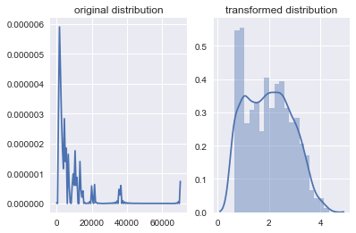

```python
from scipy.stats import boxcox, boxcox_normplot, boxcox_normmax
import numpy as np
import pandas as pd
from matplotlib import pyplot as plt
import seaborn as sb
%matplotlib inline

def compare(original, convertedData):
    fig = plt.figure()
    ax0 = plt.subplot(121)
    ax0.set_title('original distribution')
    sb.distplot(original, hist=False)
    ax1 = plt.subplot(122)
    ax1.set_title('transformed distribution')
    sb.distplot(convertedData, hist=True)
    fig.show()

def getBestLmbda(original):
    lmbda = boxcox_normmax(original)
    return lmbda

data = pd.read_csv('boxcoxSample.csv')
original = np.array(data.iloc[:,-1]) + 1  # boxcox要取log，不能有非正数
sigma = 2  # 定义标准偏差个数，右手区间以外的值会被省略

lmbda = getBestLmbda(original)
if lmbda < 0.01 and -0.01 < lmbda:
    convertedData = np.log(original)
else:
    convertedData = ((original)**lmbda - 1) / lmbda

# 画个图比较一下
compare(original, convertedData)

# 截取有效数据：
stddev = np.std(convertedData)  # 计算近似为正态分布的标准偏差
avg = np.mean(convertedData)  # 计算正态分布的平均值
cutoff = avg + stddev * sigma  # 计算截断的界限
incl = convertedData < cutoff  # 标注在界限以内的数据
kept = data.loc[incl,:]
# 一般来说就取这个范围里的最大值作为多任务的任务个数上限就可以了
maxNumberOfJobs = np.max(kept)
```

### 附2：人员活动范围计算

1. 输入数据默认为相等时间间隔内的位置数据（经纬度数据）。由于时间间隔相等，求重心直接使用平均值。函数centerOfGravity。
2. 在全天时间范围内可以用用户指定的方法划分时间区域，比如“早晨”，“工作时间”，“下班后”等等。根据时间划分会计算不同的重心。函数getTimePeriod和calculatePeriod。
3. 计算[球面距离](http://www.movable-type.co.uk/scripts/latlong.html)（假设为地面直线距离）：
   - 格式转换：经纬度数 -> 弧度：$ radian = degree * \cfrac{\pi}{180} $
   - haversine：$ h=sin^2(\Delta \phi /2) + cos \phi_1 \cdot cos \phi_2 \cdot sin^2(\Delta \lambda /2) $，其中 $\phi $是纬度，$\lambda$是经度。
   - distance: $ d = 2R \cdot atan2(\sqrt{h}, \sqrt{1-h} ) $，其中R=6371km，是地球的半径，[atan2](https://en.wikipedia.org/wiki/Atan2)是four quadrant inverse tangent.

代码实现在centerOfGravity.py

```python
import math

def centerOfGravity(positionInfo, dimension = ['USER_ID', 'timePeriod']):
    coln = ['LONGITUDE', 'LATITUDE'] + dimension
    tbl = positionInfo.loc[:, coln]
    aggTbl = tbl.groupby(dimension, as_index=False).mean()
    pivotTbl = aggTbl.pivot_table(values = ['LONGITUDE', 'LATITUDE'],
                                  index = 'USER_ID', columns = 'timePeriod')
    return pivotTbl

def getTimePeriod(positionInfo, separator={6:'morning', 8: 'workhour',
                                           17:'afterwork', 21:'night'}):
    positionInfo['hour'] = positionInfo.CREATION_DATE.apply(lambda x: x.hour)
    positionInfo['timePeriod'] = positionInfo['hour'].apply(lambda x:
                                                calculatePeriod(x, separator))
    return positionInfo

def calculatePeriod(hour, separator):
    sep = np.array(list(separator.keys()))

    idx = np.sum(hour > sep) - 1
    if idx < 0: idx = len(sep) - 1

    return separator[sep[idx]]

def getDistanceFromLatLonInKm(lat1,lon1,lat2,lon2):
    if np.isnan(lat1 * lon1 * lat2 * lon2):
        return 0

    R = 6371  # Radius of the earth in km
    dLat = deg2rad(lat2-lat1)  # deg2rad below
    dLon = deg2rad(lon2-lon1);
    a = (   math.sin(dLat/2) * math.sin(dLat/2)
            + math.cos(deg2rad(lat1)) * math.cos(deg2rad(lat2)) *
              math.sin(dLon/2) * math.sin(dLon/2)    )

    c = 2 * math.atan2(math.sqrt(a), math.sqrt(1-a))
    d = R * c  # Distance in km
    return d

def deg2rad(deg):
    return deg * (math.pi / 180)

def getDistance(_pivotTbl, startPos='night', endPos='workhour'):
    start = _pivotTbl.xs(startPos, level = 'timePeriod', axis=1)
    start.columns = ['lat1', 'lon1']
    end = _pivotTbl.xs(endPos, level = 'timePeriod', axis=1)
    end.columns = ['lat2', 'lon2']
    tmp = pd.concat([start, end], axis=1)

    _pivotTbl['distance'] = tmp.apply(lambda row:
         getDistanceFromLatLonInKm(row['lat1'],row['lon1'],
                                   row['lat2'],row['lon2']), axis=1)
    return _pivotTbl

positionInfo = pd.read_excel('user_gps_history_doc.xlsx')
timeSeparator = {6:'morning', 8: 'workhour', 17:'afterwork', 21:'night'}
positionInfo = getTimePeriod(positionInfo, timeSeparator)
area = centerOfGravity(positionInfo)
area = getDistance(area, startPos='night', endPos='workhour')

area
```

| timePeriod USER_ID | LATITUDE afterwork | LATITUDE morning | LATITUDE night | LATITUDE workhour | LONGITUDE afterwork | LONGITUDE morning | LONGITUDE night | LONGITUDE workhour | distance |
| --- | --- | --- | --- | --- | --- | --- | --- | --- | --- |
| 79224 | NaN | 52.086786 | 52.751173 | 53.177631 | NaN | 23.695986 | 25.062348 | 25.993367 | 78.335872 |
| 82006 | NaN | 16.276630 | 15.838041 | 17.665191 | NaN | 120.394907 | 120.481484 | 120.523651 | 203.219337 |
| 82501 | 0.475384 | NaN | 1.101723 | 0.392704 | 101.470588 | NaN | 104.131130 | 100.895873 | 368.249776 |
| 82706 | -5.634121 | -5.560931 | -5.491557 | -4.897822 | 114.557036 | 113.950764 | 114.609420 | 117.622581 | 340.138941 |
| 97179 | 13.799101 | 14.029056 | 14.091144 | 14.776764 | 100.527038 | 100.552136 | 100.544120 | 100.465440 | 76.706746 |
| 122996 | NaN | NaN | -11.950171 | -10.210436 | NaN | NaN | 29.202643 | 31.189430 | 290.554374 |